# 111617meet

$\textbf{Just use main effect cutoff to repeatedly cut down the size of data}$

```r
library(MASS)
library(randomForestSRC)

ro<-0.5
n=100
p=100

design.cov <- function(p, cov.x, equalCorr=F){
  if (!equalCorr){
    x <- matrix(0,p,p)
    for(i in 1:p){
      x[i,(i:p)] <- cov.x^(0:(p - i))
      x[i,(1:(i - 1))] <- x[(1:(i - 1)),i]
    }
  }
  else{
    x <- matrix(cov.x,p,p)
    diag(x) <- 1
  }
  return(x)
}

mvngeneration <- function(n, p, varcov){
  choleski <- chol(varcov)
  tcholeski <- t(choleski)
  z <- matrix(rnorm(p * n, 0, 1), p, n)
  tranx <- tcholeski %*% z
  x <- t(tranx)
  x
}

simdata<- mvngeneration(n, p, design.cov(p, ro))

simdata<-t(simdata)
rownames(simdata)<-paste("x",1:100,sep="") ##p
colnames(simdata)<-paste("id",1:100,sep="") ##n

##result<-rep(0,n)
##for(i in 1:p){result<-result+simdata[i,]}
result<-simdata[4,]*simdata[87,]

training<-t(simdata)

data<-data.frame(result,training)
names(data)[1]<-c("y")

formula<-y~.

fNames <- all.vars(formula, max.names=1e7)

##Repeat the following procedure
while(length(data)>5){
  var.columns <- (1:ncol(data))[-c(which(names(data) == fNames[1]))]

  sim.out<-rfsrc(formula,data)
  sim.int<-find.interaction(sim.out,method="maxsubtree")

  sim.diag<-diag(sim.int)
  threshold1<-mean(sim.diag)
  var.pt1<-which(sim.diag<threshold1)
  idx<-match(colnames(sim.int),colnames(data))
  var.pt<-idx[var.pt1]
  drop.var.pt <- setdiff(var.columns, var.pt)
  data<-data[,-drop.var.pt]
}
```

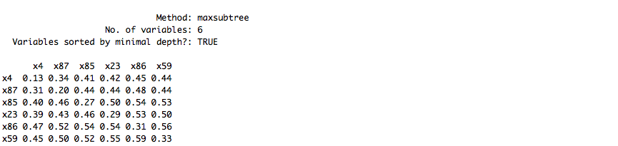

Here, I generate my $y$ on interaction of $x_{4}$ and $x_{87}$. I also tried different values of $p$ and as long as $p$ is comparable to $n$, this procedure is fine to catch the interactive pair. Now I keep increasing size of $p$ to see what changes wwould happen.

```r
library(MASS)
library(randomForestSRC)

ro<-0.5
n=100
p=500

design.cov <- function(p, cov.x, equalCorr=F){
  if (!equalCorr){
    x <- matrix(0,p,p)
    for(i in 1:p){
      x[i,(i:p)] <- cov.x^(0:(p - i))
      x[i,(1:(i - 1))] <- x[(1:(i - 1)),i]
    }
  }
  else{
    x <- matrix(cov.x,p,p)
    diag(x) <- 1
  }
  return(x)
}

mvngeneration <- function(n, p, varcov){
  choleski <- chol(varcov)
  tcholeski <- t(choleski)
  z <- matrix(rnorm(p * n, 0, 1), p, n)
  tranx <- tcholeski %*% z
  x <- t(tranx)
  x
}

simdata<- mvngeneration(n, p, design.cov(p, ro))

simdata<-t(simdata)
rownames(simdata)<-paste("x",1:500,sep="") ##p
colnames(simdata)<-paste("id",1:100,sep="") ##n

##result<-rep(0,n)
##for(i in 1:p){result<-result+simdata[i,]}
result<-simdata[4,]*simdata[287,]

training<-t(simdata)

data<-data.frame(result,training)
names(data)[1]<-c("y")

formula<-y~.

fNames <- all.vars(formula, max.names=1e7)

##Repeat the following procedure
while(length(data)>5){
  var.columns <- (1:ncol(data))[-c(which(names(data) == fNames[1]))]

  sim.out<-rfsrc(formula,data)
  sim.int<-find.interaction(sim.out,method="maxsubtree")

  sim.diag<-diag(sim.int)
  threshold1<-mean(sim.diag)
  var.pt1<-which(sim.diag<threshold1)
  idx<-match(colnames(sim.int),colnames(data))
  var.pt<-idx[var.pt1]
  drop.var.pt <- setdiff(var.columns, var.pt)
  data<-data[,-drop.var.pt]
}
```

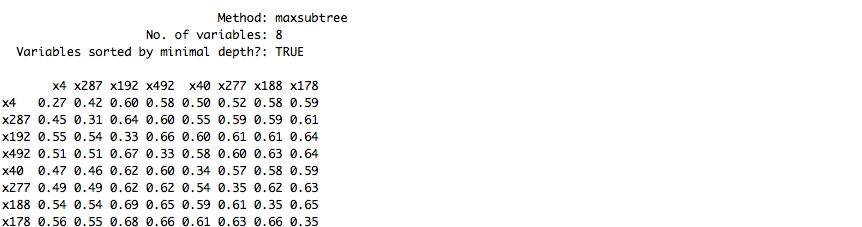

Sometimes we could still get pretty good result that this pair does have smallest between depth among all. But sometimes not. So weight using between depth information is to be considered.  
What about 3-way interaction?

```r
library(MASS)
library(randomForestSRC)

ro<-0.5
n=100
p=500

design.cov <- function(p, cov.x, equalCorr=F){
  if (!equalCorr){
    x <- matrix(0,p,p)
    for(i in 1:p){
      x[i,(i:p)] <- cov.x^(0:(p - i))
      x[i,(1:(i - 1))] <- x[(1:(i - 1)),i]
    }
  }
  else{
    x <- matrix(cov.x,p,p)
    diag(x) <- 1
  }
  return(x)
}

mvngeneration <- function(n, p, varcov){
  choleski <- chol(varcov)
  tcholeski <- t(choleski)
  z <- matrix(rnorm(p * n, 0, 1), p, n)
  tranx <- tcholeski %*% z
  x <- t(tranx)
  x
}

simdata<- mvngeneration(n, p, design.cov(p, ro))

simdata<-t(simdata)
rownames(simdata)<-paste("x",1:500,sep="") ##p
colnames(simdata)<-paste("id",1:100,sep="") ##n

##result<-rep(0,n)
##for(i in 1:p){result<-result+simdata[i,]}
result<-simdata[4,]*simdata[96,]*simdata[287,]

training<-t(simdata)

data<-data.frame(result,training)
names(data)[1]<-c("y")

formula<-y~.

fNames <- all.vars(formula, max.names=1e7)

##Repeat the following procedure
while(length(data)>5){
  var.columns <- (1:ncol(data))[-c(which(names(data) == fNames[1]))]

  sim.out<-rfsrc(formula,data)
  sim.int<-find.interaction(sim.out,method="maxsubtree")

  sim.diag<-diag(sim.int)
  threshold1<-mean(sim.diag)
  var.pt1<-which(sim.diag<threshold1)
  idx<-match(colnames(sim.int),colnames(data))
  var.pt<-idx[var.pt1]
  drop.var.pt <- setdiff(var.columns, var.pt)
  data<-data[,-drop.var.pt]
}
```

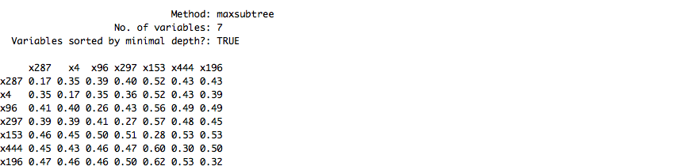

Now I directly try with 500 features and 100 sample size case. The result is as above. I tried several times and get good result most of the tries.

$\textbf{Try of iRF on my multivariate simulation data}$

```r
library(MASS)
library(randomForestSRC)

ro<-0.5
n=100
p=50

design.cov <- function(p, cov.x, equalCorr=F){
  if (!equalCorr){
    x <- matrix(0,p,p)
    for(i in 1:p){
      x[i,(i:p)] <- cov.x^(0:(p - i))
      x[i,(1:(i - 1))] <- x[(1:(i - 1)),i]
    }
  }
  else{
    x <- matrix(cov.x,p,p)
    diag(x) <- 1
  }
  return(x)
}

mvngeneration <- function(n, p, varcov){
  choleski <- chol(varcov)
  tcholeski <- t(choleski)
  z <- matrix(rnorm(p * n, 0, 1), p, n)
  tranx <- tcholeski %*% z
  x <- t(tranx)
  x
}

simdata<- mvngeneration(n, p, design.cov(p, ro))

simdata<-t(simdata)
rownames(simdata)<-paste("x",1:50,sep="")
colnames(simdata)<-paste("id",1:100,sep="")

##result<-rep(0,n)
##for(i in 1:p){result<-result+simdata[i,]}
result<-10*simdata[4,]*simdata[17,]

training<-t(simdata)

data<-data.frame(result,training)
names(data)[1]<-c("y")

formula<-y~.

fNames <- all.vars(formula, max.names=1e7)
x<-as.matrix(data[,-1])
y<-as.matrix(data[,1])
library(iRF)
iRF(y=y, x=x, interactions.return=1:5, n.iter=5,
    nodesize=10, n.bootstrap=10, ntree=500, n.core=24)
```

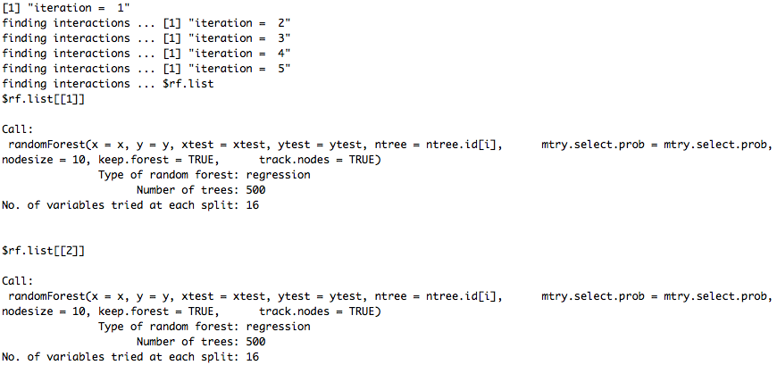

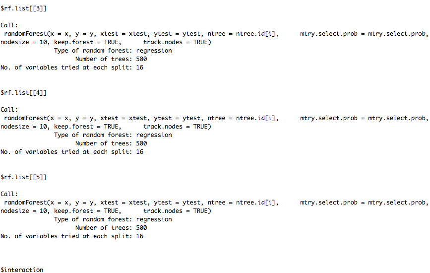

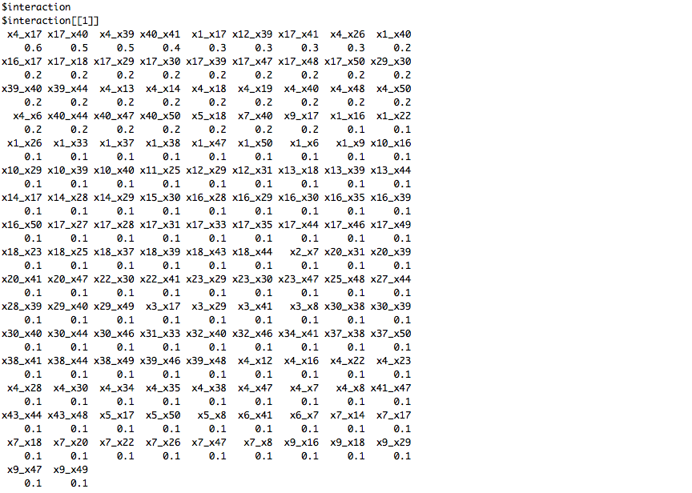

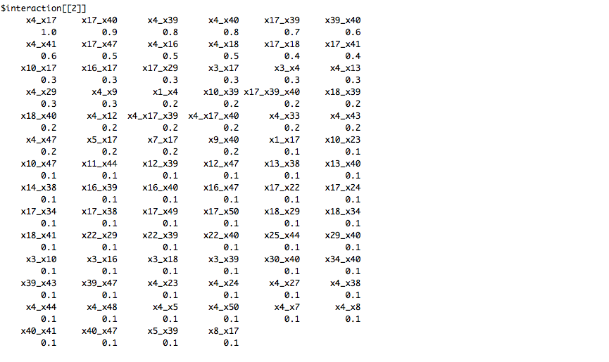

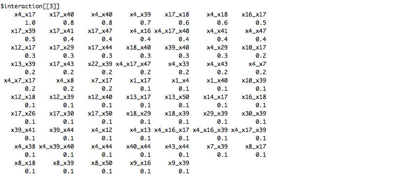

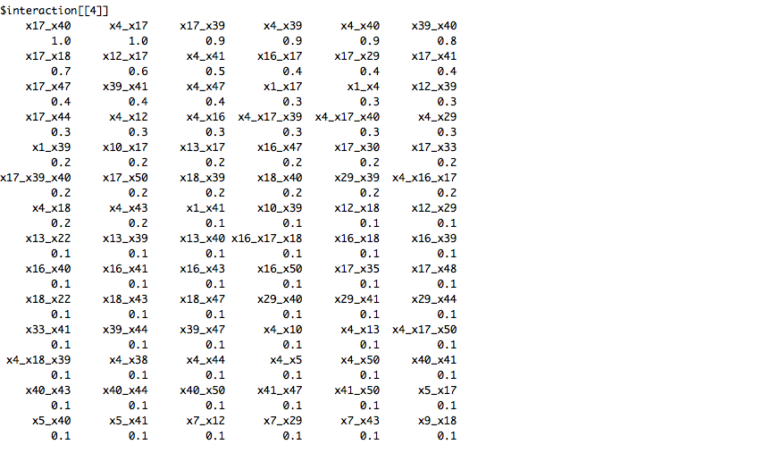

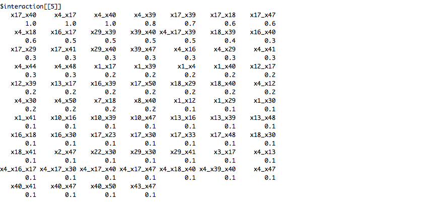

This is a small case to give it a try because my laptop is pretty slow at running it.  
I sampled 50 features from multivariate case and my $y$ is generated as $10*x_{4}*x_{17}$ and my sample size is 100. I put coefficient to be $10$ to enlarge the signal so that it would be easier to detect. Well the last two lines of above code displays setting the parameters. The result is good that the $x_{4}$, $x_{17}$ pair always rank high with high stability score. There are still pairs like $x_{17}$ and $x_{40}$ to behave like a important interactive pair, but we should be able to identify and get stable result over more iterations.

I just used the rule setting OR and injected noise by swapping the labels for $10%$, $15%$ and $20%$ of the responses selected at random. The threshold is set as $t_{OR}=3.2$. the sample of size is set to be 100. (I know this is probably not large enough, but my laptop was running slow so I just tried 100 sample size.) And for the same reason, I simulated 2 times instead of 20 times in orignal paper setting to asses variability in both prediction accuracy and interaction recovery for iterations $k\in {1,2,...,5}$ of iRF.

```r
library(iRF)

runSim <- function(n, p, x.params, y.params, dir, seed, n.cores=1) {
  set.seed(seed)
  x <- genX(n, x.params)
  y <- genY(x, y.params)
  ns <- ifelse(is.factor(y), 1, 10)
  if (!is.null(x.params$cov)) x.params$cov <- NULL

  int.return <- 1:5
  fit <- iRF(y=y, x=x,
             interactions.return=int.return,
             n.iter=max(int.return),
             nodesize=ns,
             n.bootstrap=20,
             ntree=500,
             n.core=n.cores)

  gini.x <- decreaseGiniWrapper(x, y)
  file <- paste0(dir, 'iter', seed, '.Rdata')
  save(file=file, fit, gini.x, x.params, y.params)
}

genX <- function(n, x.params) {
  p <- x.params$p
  x <- matrix(rcauchy(n*p), nrow=n)
  return(x)
}

genOR <- function(x, tt, active.set=1:4) {
  stopifnot(ncol(x) >= max(active.set))
  y <- apply(x[,active.set] > tt, MAR=1, any)
  return(y)
}

genY <- function(x, y.params) {
  n <- nrow(x)
  p <- ncol(x)

  y <- genOR(x, y.params$thresh, y.params$active)

  if (y.params$noise == 0) {
    y <- as.factor(as.numeric(y))
  } else if (y.params$classification) {
    n.class <- trunc(table(y) * y.params$noise)
    idcs.swap <- mapply(function(cc, nn)
      sample(which(y == cc), nn, replace=TRUE),
      as.factor(names(n.class)), n.class)
    idcs.swap <- unlist(idcs.swap)
    y[idcs.swap] <- ifelse(y[idcs.swap], FALSE, TRUE)
    y <- as.factor(as.numeric(y))
  } else {
    y <- as.numeric(y) + rnorm(n, sd=y.params$noise)
  }
  return(y)
}


gini <- function(y) {
  if (is.factor(y)) yy <- as.numeric(y) - 1
  else yy <- y
  return(1 - mean(yy) ^ 2 - mean(1 - yy) ^ 2)
}

decreaseGini <- function(x, y) {
  n <- length(y)
  gini.y <- gini(y)
  x.order <- order(x)
  y.sort <- y[x.order]
  split.gini <- sapply(1:(n-1), function(i)
    c(gini(y.sort[1:i]), gini(y.sort[-(1:i)])))
  weights <- rbind(1:(n-1), (n-1):1)
  child.gini <- colSums(weights * split.gini) / n
  dec.gini <- gini.y - min(child.gini)

  return(c(y.gini=gini.y, child.gini=min(child.gini), dec.gini=dec.gini))
}

decreaseGiniWrapper <- function(x, y) {
  gg <- apply(x, MAR=2, decreaseGini, y)
  return(gg)
}


n.cores <- 24

x.params <- list()
x.params$dist <- 'cauchy'
y.params <- list()
y.params$classification <- TRUE

thresh <- 3.2
noises <- c(0.1, 0.15, 0.2)
p <- 50
n <- 100
active <- 1:5


for (noise in noises) {
  print(paste('P:', p, 'N:', n))
  x.params$p <- p
  y.params$noise <- noise
  y.params$thresh <- thresh

  y.params$thresh <- thresh
  rr <- paste0('or', '_', y.params$thresh, '_Identity')
  y.params$active.set <- active
  y.params$k <- length(active)

  dir <- paste0('./booleanSims/noise_', noise, '/', rr, '/', 'nObs_', n, '/')
  dir.create(dir, recursive=TRUE)
  iters <- 1:2
  lapply(iters, function(ii) runSim(n, p, x.params, y.params, dir, ii, n.cores))
}
```

The following is part of result to be shown, I chose the fit for the $1^{st}$ iteration with $10%$ noise to display:

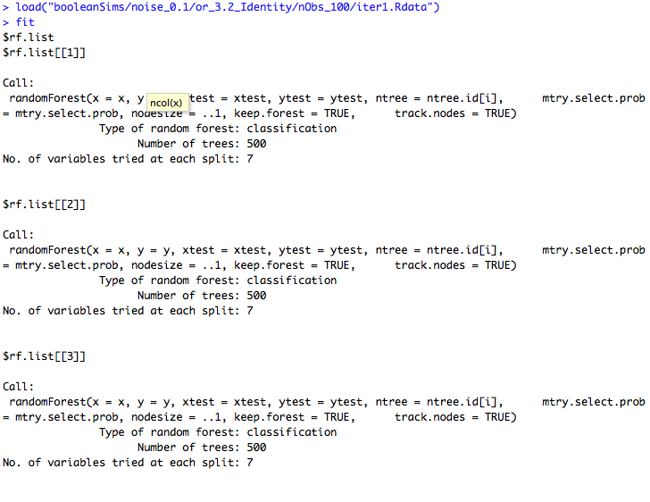

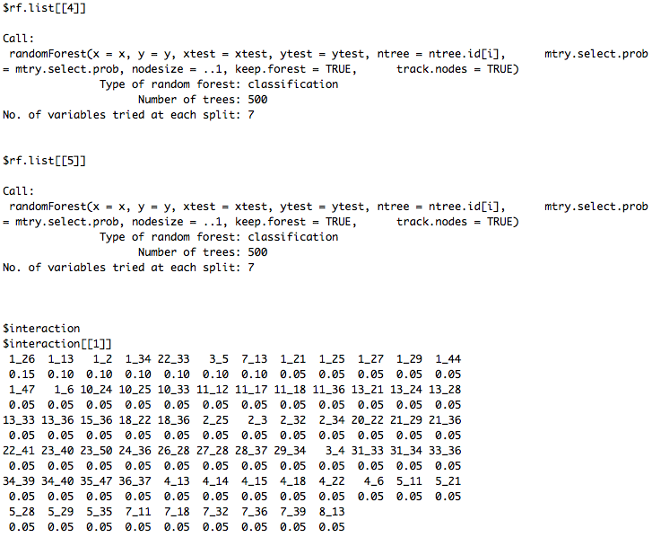

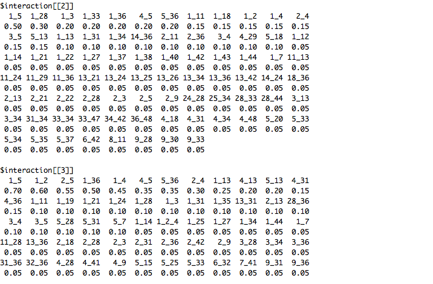

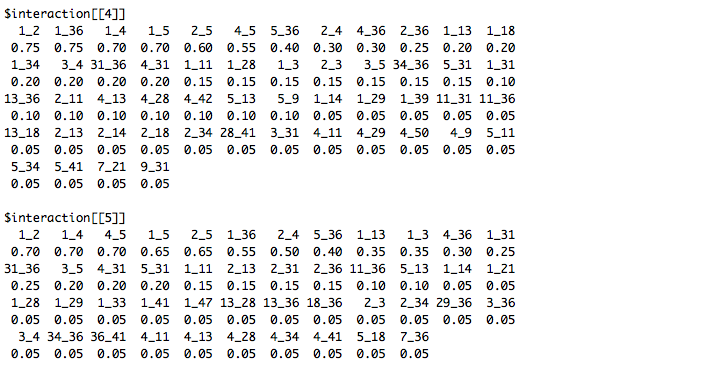